# Projeto de Fundamentos da Ciência de Dados: Análise de dados do FoodHub

**Pontos: 60**

### Contexto

O número de restaurantes em Nova Iorque aumenta dia após dia. Muitos estudantes e profissionais ocupados dependem destes restaurantes devido aos seus estilos de vida agitados. O serviço de entrega de comida online é uma ótima opção para eles. Desta forma, é proporcionado boa comida de seus restaurantes favoritos. Uma empresa agregadora de alimentos, FoodHub, oferece acesso a múltiplos restaurantes através de um único aplicativo de smartphone.

O aplicativo permite que os restaurantes recebam uma encomenda de um cliente diretamente online. O aplicativo designa um entregador da empresa para buscar a encomenda após a confirmação do restaurante. O entregador utiliza um gps para chegar ao restaurante e espera pela encomenda. Assim que o pacote é entregue ao entregador, é confirmado pelo aplicativo e o entregador inicia a viagem até a localização do cliente para a entrega do pacote. O entregador confirma a entrega pelo aplicativo após a entrega do pacote. O cliente pode avaliar a encomenda na aplicação. O agregador de alimentos ganha dinheiro ao recolher uma margem fixa da ordem de entrega nos restaurantes.

### Objetivo

A empresa agregadora de alimentos armazenou os dados de diferentes pedidos feitos pelos clientes registados em seu portal online. Eles querem analisar os dados para ter uma ideia da procura dos diferentes restaurantes, que os ajudará a melhorar a experiência de seus clientes. Suponha que você é contratado como cientista de dados nesta empresa e a equipe de ciência de dados compartilhou algumas das questões-chave que precisam ser respondidas. Realize a análise de dados para encontrar respostas a estas perguntas que ajudarão a empresa a melhorar o negócio.

### Descrição de dados

Os dados contêm os diferentes dados relacionados aos pedidos de comida. O dicionário de dados é apresentado abaixo.

### Dicionário de dados

- order_id: ID exclusivo do pedido
- customer_id: ID do cliente que fez o pedido
- restaurant_name: Nome do restaurante
- cuisine_type: Tipo de culinária do pedido
- cost_of_the_order: Custo do pedido
- day_of_the_week: Indica se o pedido é feito durante a semana ou de fim de semana (Durante a semana é de segunda a sexta e o fim de semana é sábado e domingo)
- rating: Avaliação dada pelo cliente de 1 a 5
- food_preparation_time: Tempo (em minutos) gasto pelo restaurante para preparar a comida. Isto é calculado através da diferença de indicação de tempo da confirmação de pedido pelo restaurante e da confirmação de recebimento do pacote do entregador.
- delivery_time: Tempo (em minutos) tomado pelo entregador para entregar o pedido. Isto é calculado através da diferença de indicação de tempo entre a confirmação de recebimento do pacote do entregador e a informação de entrega

### Vamos começar importando as bibliotecas necessárias

```python
# import libraries for data manipulation
import numpy as np
import pandas as pd

# import libraries for data visualization
import matplotlib.pyplot as plt
import seaborn as sns
```

### Entendendo a estrutura dos dados

```python
# uncomment and run the following lines for Google Colab
# from google.colab import drive
# drive.mount('/content/drive')
```

```python
# read the data
df = pd.read_csv('foodhub_order.csv')
# returns the first 5 rows
df.head()
```

|  | order_id | customer_id | restaurant_name | cuisine_type | cost_of_the_order | day_of_the_week | rating | food_preparation_time | delivery_time |
| --- | --- | --- | --- | --- | --- | --- | --- | --- | --- |
| 0 | 1477147 | 337525 | Hangawi | Korean | 30.75 | Weekend | Not given | 25 | 20 |
| 1 | 1477685 | 358141 | Blue Ribbon Sushi Izakaya | Japanese | 12.08 | Weekend | Not given | 25 | 23 |
| 2 | 1477070 | 66393 | Cafe Habana | Mexican | 12.23 | Weekday | 5 | 23 | 28 |
| 3 | 1477334 | 106968 | Blue Ribbon Fried Chicken | American | 29.20 | Weekend | 3 | 25 | 15 |
| 4 | 1478249 | 76942 | Dirty Bird to Go | American | 11.59 | Weekday | 4 | 25 | 24 |

#### Observações:

A estrutura de dados possui 9 colunas conforme mencionado no dicionário de dados. Os dados em cada linha correspondem a um pedido feito por um cliente.

### **Pergunta 1:** Quantas linhas e colunas estão presentes nos dados? [0.5 pontos]

```python
# Write your code here
df.shape
#A função shape apresenta a quantidade linhas e colunas de um DataFrame.
```

```
(1898, 9)
```

#### Observações:

O conjunto de dados analisados apresenta 1898 linhas e 9 colunas.

### **Pergunta 2:** Quais são os tipos de dados das diferentes colunas no conjunto de dados? (A função info() pode ser usada) [0.5 pontos]

```python
# Use info() to print a concise summary of the DataFrame
df.info()
```

```
<class 'pandas.core.frame.DataFrame'>
RangeIndex: 1898 entries, 0 to 1897
Data columns (total 9 columns):
 #   Column                 Non-Null Count  Dtype
---  ------                 --------------  -----
 0   order_id               1898 non-null   int64
 1   customer_id            1898 non-null   int64
 2   restaurant_name        1898 non-null   object
 3   cuisine_type           1898 non-null   object
 4   cost_of_the_order      1898 non-null   float64
 5   day_of_the_week        1898 non-null   object
 6   rating                 1898 non-null   object
 7   food_preparation_time  1898 non-null   int64
 8   delivery_time          1898 non-null   int64
dtypes: float64(1), int64(4), object(4)
memory usage: 133.6+ KB
```

#### Observações:

- Existem três tipos de dados diferentes - float64 (representa variáveis numéricas reais/flutuantes), int64 (representa variáveis numéricas inteiras) e objeto (representa variáveis categóricas)
- Existe 1 coluna numérica real/flutuante - `cost_of_the_order`
- Existem 4 colunas numéricas inteiras - `order_id, customer_id, food_preparation_time, delivery_time`
- Existem 4 colunas categóricas - `restaurant_name, cuisine_type, day_of_the_week, rating`
- A variavel `rating` é categórica, mas poderia ser numérica se todos os pedidos possuissem avaliação, pois o valor para registros sem avaliação possuem o valor armazenado 'Not given', o que torna esta coluna categórica também.

### **Pergunta 3:** Há algum valor ausente nos dados? Se sim, lide com eles utilizando um método apropriado. [1 ponto]

```python
# Write your code here
df.isnull().values.any()
#- df.isnull(): Cria um DataFrame booleano com o mesmo formato do DataFrame original, onde cada elemento é True se o valor correspondente no DataFrame original for nulo, e False caso contrário.
#- .values: Converte o DataFrame booleano em uma matriz NumPy.
#- .any(): Retorna True se pelo menos um valor na matriz NumPy for True, indicando que há pelo menos um valor nulo no DataFrame original.
```

```
False
```

#### Observações:

A expressão df.isnull().values.any() é utilizada para verificar se há valores nulos (ausentes) em um DataFrame e como o resultado do código acima é (False) implica que **não há valores ausentes nos dados analisados**.

Se existesse algum valor nulo (ausente) uma solução mais apropriada seria preencher o valor nulo com algum valor específico.

Ex:

- Preencher valores nulos com zero: df_preenchido = df.fillna(0)

### **Pergunta 4:** Verifique o resumo estatístico dos dados. Qual é o tempo mínimo, médio e máximo que a comida leva para ser preparada após o pedido ser feito? [2 pontos]

```python
# Write your code here
df.describe()
# A função describe traz o resumo estatístico do DataFrame
```

|  | order_id | customer_id | cost_of_the_order | food_preparation_time | delivery_time |
| --- | --- | --- | --- | --- | --- |
| count | 1.898000e+03 | 1898.000000 | 1898.000000 | 1898.000000 | 1898.000000 |
| mean | 1.477496e+06 | 171168.478398 | 16.498851 | 27.371970 | 24.161749 |
| std | 5.480497e+02 | 113698.139743 | 7.483812 | 4.632481 | 4.972637 |
| min | 1.476547e+06 | 1311.000000 | 4.470000 | 20.000000 | 15.000000 |
| 25% | 1.477021e+06 | 77787.750000 | 12.080000 | 23.000000 | 20.000000 |
| 50% | 1.477496e+06 | 128600.000000 | 14.140000 | 27.000000 | 25.000000 |
| 75% | 1.477970e+06 | 270525.000000 | 22.297500 | 31.000000 | 28.000000 |
| max | 1.478444e+06 | 405334.000000 | 35.410000 | 35.000000 | 33.000000 |

#### Observações:

O tempo de preparação (em minutos) da comida fica armazenado na coluna `food_preparation_time`, e seu resumo estatístico é:

- Tempo mínimo: 20 minutos
- Tempo médio: 27.37 minutos
- Tempo máximo: 35 minutos

### **Pergunta 5:** Quantos pedidos não foram avaliados? [1 ponto]

```python
# Write the code here
# Podemos extrair a informação usando a função count_nonzero do Numpy
# Em conjunto com a expressão de extrai da coluna rating somente os pedidos não avaliados (valor: 'Not given')
# Lembrar de extrair somente uma coluna de dados, senão a função contará a quantidade de linhas vezes as colunas
pedidos_sem_avaliacao = np.count_nonzero(df[df['rating']=='Not given']['rating'])
print("Não foram avaliados", pedidos_sem_avaliacao, "pedidos")

# Podemos usar também a função value_counts() para fazer esta contagem de pedidos agrupando pelo rating (avaliação)
# Como retorno teremos a quantidade de pedidos para cada valor avaliado e também para a quantidade de pedidos não avaliados
df['rating'].value_counts()
```

```
Não foram avaliados 736 pedidos
```

```
rating
Not given    736
5            588
4            386
3            188
Name: count, dtype: int64
```

#### Observações:

Em ambos códigos usados, chegamos na solução de que foram 736 pedidos não avaliados.

### Análise Exploratória de Dados (EDA)

### **Pergunta 6:** Explore todas as variáveis e forneça observações sobre suas distribuições. (Geralmente, histogramas, boxplots, countplots, etc. são usados para exploração univariada.) [9 pontos]

```
Foram feitos 1898 pedidos no total.
Por 1200 clientes.

São 178 restaurantes com pedidos registrados.
Com 14 culinárias diferentes.
```

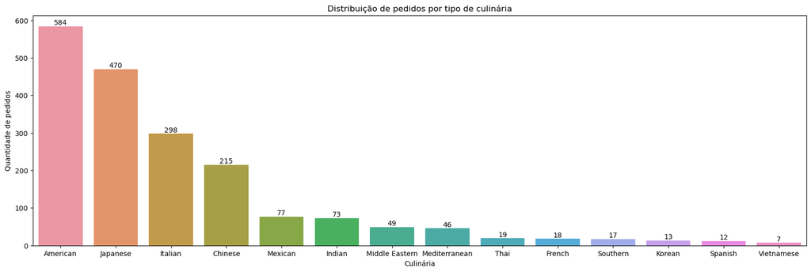

```python
# Write the code here

# Visualização de dados únicos (com menor distribuição)

# order_id e customer_id

# Extrair a informação da quantidade de valores únicos das colunas order_id e customer_id. E imprimir estes valores.
qtd_pedidos = df['order_id'].nunique()
qtd_clientes = df['customer_id'].nunique()
print("Foram feitos", qtd_pedidos, "pedidos no total.\nPor", qtd_clientes, "clientes.\n")

# restaurant_name e cuisine_type

# Extrair a informação da quantidade de valores únicos das colunas restaurant_name e cuisine_type. E imprimir estes valores.
qtd_restaurantes = df['restaurant_name'].nunique()
qtd_culinarias = df['cuisine_type'].nunique()
print("São", qtd_restaurantes, "restaurantes com pedidos registrados.\nCom", qtd_culinarias, "culinárias diferentes.")

# Visualização dos dados com maior distribuição

# cuisine_type

# Ajuste do tamanho da figura para distribuição de pedidos por tipo de culinária
plt.figure(figsize=(20, 6))

# Defina a paleta de cores desejada
sns.set_palette("husl")

# Contagem dos tipos de culinaria em ordem decrescente
contagem_ordem_decrescente = df['cuisine_type'].value_counts().sort_values(ascending=False)

# Impressão do gráfico da distribuição de pedidos por tipo de culinária
sns.countplot(data=df, x='cuisine_type',order=contagem_ordem_decrescente.index)
plt.xlabel("Culinária")
plt.ylabel("Quantidade de pedidos")
plt.title("Distribuição de pedidos por tipo de culinária")

# Adicione as contagens sobre cada barra
for i, v in enumerate(contagem_ordem_decrescente):
    plt.text(i, v + 0.1, str(v), ha='center', va='bottom')

plt.show()
```

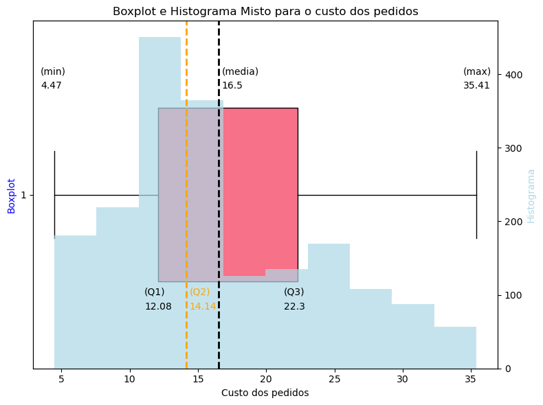

```python
# cost_of_the_order

# Visualização de dados usando gráfico misto de boxplot e histograma para a coluna cost_of_the_order
# Criando a figura e os eixos
fig, ax = plt.subplots(figsize=(8, 6))

# Defina a paleta de cores desejada
sns.set_palette("husl")

# Boxplot
ax.boxplot(df['cost_of_the_order'], vert=False, patch_artist=True, widths=0.50)

# Histograma
hist_axes = ax.twinx()
hist_axes.hist(df['cost_of_the_order'], bins=10,color='lightblue', alpha=0.7)

# Adicionando rótulos e título
ax.set_xlabel('Custo dos pedidos')
ax.set_ylabel('Boxplot', color='blue')
hist_axes.set_ylabel('Histograma', color='lightblue')
ax.set_title('Boxplot e Histograma Misto para o custo dos pedidos')

#inserindo linhas para Q1, Q3, mediana(Q2) e media
plt.text(x = df['cost_of_the_order'].min()-1, y = 400, s = '(min)')
plt.text(x = df['cost_of_the_order'].min()-1, y = 380, s = df['cost_of_the_order'].min())
#q1 = df['cost_of_the_order'].quantile(0.25)  # valor Q1
#plt.axvline(x=q1, color='red', linestyle='dashed', linewidth=2, label='Linha Q1')
plt.text(x = df['cost_of_the_order'].quantile(0.25)-1, y = 100, s = '(Q1)')
plt.text(x = df['cost_of_the_order'].quantile(0.25)-1, y = 80, s = df['cost_of_the_order'].quantile(0.25))
#q3 = df['cost_of_the_order'].quantile(0.75)  # valor Q3
#plt.axvline(x=q3, color='red', linestyle='dashed', linewidth=2, label='Linha Q3')
plt.text(x = df['cost_of_the_order'].quantile(0.75)-1, y = 100, s = '(Q3)')
plt.text(x = df['cost_of_the_order'].quantile(0.75)-1, y = 80, s = round(df['cost_of_the_order'].quantile(0.75),2))
mediana = df['cost_of_the_order'].median()  # mediana(Q2)
plt.axvline(x=mediana, color='orange', linestyle='dashed', linewidth=2, label='Linha da mediana(Q2)')
plt.text(x = df['cost_of_the_order'].median()+0.25, y = 100, s = '(Q2)',color='orange')
plt.text(x = df['cost_of_the_order'].median()+0.25, y = 80, s = df['cost_of_the_order'].median(),color='orange')
media = df['cost_of_the_order'].mean()  # media
plt.axvline(x=media, color='black', linestyle='dashed', linewidth=2, label='Linha da média')
plt.text(x = df['cost_of_the_order'].mean()+0.25, y = 400, s = '(media)')
plt.text(x = df['cost_of_the_order'].mean()+0.25, y = 380, s = round(df['cost_of_the_order'].mean(),2))
plt.text(x = df['cost_of_the_order'].max()-1, y = 400, s = '(max)')
plt.text(x = df['cost_of_the_order'].max()-1, y = 380, s = df['cost_of_the_order'].max())

# Ajustando o layout
plt.tight_layout()

# Exibindo o gráfico
plt.show()
```

### Observação

Neste exemplo:

- ax.boxplot é usado para criar um boxplot.
- ax.twinx() cria um segundo eixo y compartilhado com o mesmo eixo x.
- hist_axes.hist é usado para criar um histograma no segundo eixo.

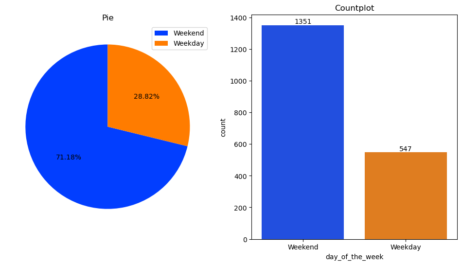

```python
# day_of_the_week

# Visualização de dados usando os gráficos pie e countplot para a coluna day_of_the_week

# Defina a paleta de cores desejada
sns.set_palette("bright")

# Criando a figura e os subgráficos
fig, axs = plt.subplots(1, 2, figsize=(12, 6))

# Defina a paleta de cores desejada
sns.set_palette("bright")

# Pie
axs[0].pie(df['day_of_the_week'].value_counts(),autopct='%.2f%%', startangle=90)
axs[0].set_title("Pie")

# Adicionando uma legenda ao gráfico Pie
axs[0].legend(df['day_of_the_week'].value_counts().index, loc='upper right')

# Countplot
sns.countplot(data = df, x= 'day_of_the_week')
axs[1].set_title('Countplot')

# Adicione as contagens sobre cada barra
for i, v in enumerate(df['day_of_the_week'].value_counts()):
    plt.text(i, v + 0.1, str(v), ha='center', va='bottom')

# Exibindo o gráfico
plt.show()
```

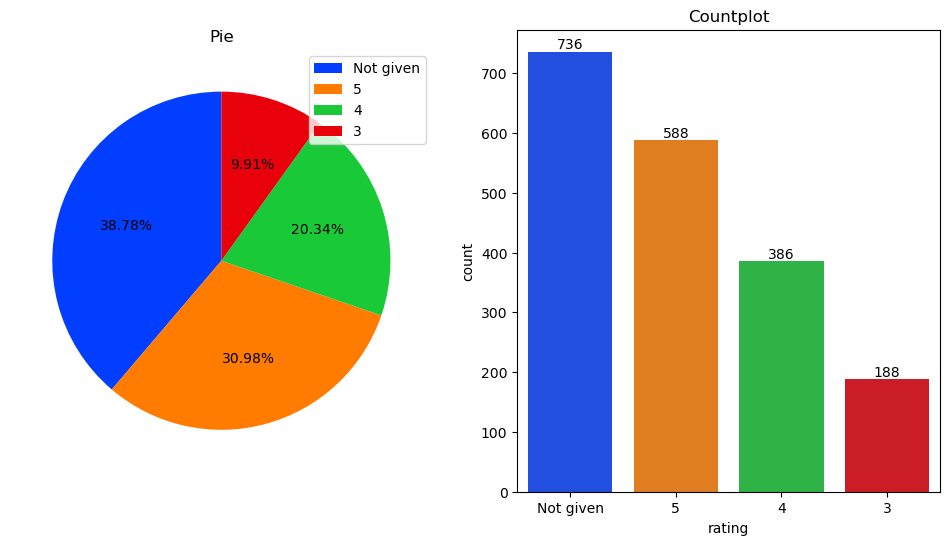

```python
# rating

# Visualização de dados usando os gráficos pie e countplot para a coluna rating

# Defina a paleta de cores desejada
sns.set_palette("bright")

# Criando a figura e os subgráficos
fig, axs = plt.subplots(1, 2, figsize=(12, 6))

# Pie
axs[0].pie(df['rating'].value_counts(),autopct='%.2f%%', startangle=90)
axs[0].set_title("Pie")

# Adicionando uma legenda ao gráfico Pie
axs[0].legend(df['rating'].value_counts().index, loc='upper right')

# Countplot
sns.countplot(data = df, x= 'rating',order=df['rating'].value_counts().sort_values(ascending=False).index)
axs[1].set_title('Countplot')

# Adicione as contagens sobre cada barra
for i, v in enumerate(df['rating'].value_counts().sort_values(ascending=False)):
    plt.text(i, v + 0.1, str(v), ha='center', va='bottom')

# Exibindo o gráfico
plt.show()
```

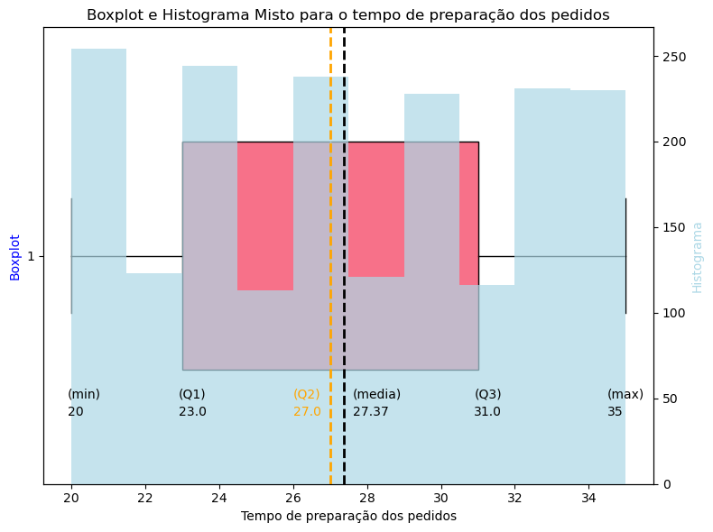

```python
# food_preparation_time

# Visualização de dados usando gráfico misto de boxplot e histograma para a coluna food_preparation_time

# Defina a paleta de cores desejada
sns.set_palette("husl")

# Criando a figura e os eixos
fig, ax = plt.subplots(figsize=(8, 6))

# Boxplot
ax.boxplot(df['food_preparation_time'], vert=False, patch_artist=True, widths=0.50)

# Histograma
hist_axes = ax.twinx()
hist_axes.hist(df['food_preparation_time'], bins=10, color='lightblue', alpha=0.7)

# Adicionando rótulos e título
ax.set_xlabel('Tempo de preparação dos pedidos')
ax.set_ylabel('Boxplot', color='blue')
hist_axes.set_ylabel('Histograma', color='lightblue')
ax.set_title('Boxplot e Histograma Misto para o tempo de preparação dos pedidos')

#inserindo linhas para Q1, Q3, mediana(Q2) e media
plt.text(x = df['food_preparation_time'].min()-0.1, y = 50, s = '(min)')
plt.text(x = df['food_preparation_time'].min()-0.1, y = 40, s = df['food_preparation_time'].min())
#q1 = df['food_preparation_time'].quantile(0.25)  # valor Q1
#plt.axvline(x=q1, color='red', linestyle='dashed', linewidth=2, label='Linha Q1')
plt.text(x = df['food_preparation_time'].quantile(0.25)-0.1, y = 50, s = '(Q1)')
plt.text(x = df['food_preparation_time'].quantile(0.25)-0.1, y = 40, s = df['food_preparation_time'].quantile(0.25))
#q3 = df['food_preparation_time'].quantile(0.75)  # valor Q3
#plt.axvline(x=q3, color='red', linestyle='dashed', linewidth=2, label='Linha Q3')
plt.text(x = df['food_preparation_time'].quantile(0.75)-0.1, y = 50, s = '(Q3)')
plt.text(x = df['food_preparation_time'].quantile(0.75)-0.1, y = 40, s = round(df['food_preparation_time'].quantile(0.75),2))
mediana = df['food_preparation_time'].median()  # mediana(Q2)
plt.axvline(x=mediana, color='orange', linestyle='dashed', linewidth=2, label='Linha da mediana(Q2)')
plt.text(x = df['food_preparation_time'].median()-1, y = 50, s = '(Q2)',color='orange')
plt.text(x = df['food_preparation_time'].median()-1, y = 40, s = df['food_preparation_time'].median(),color='orange')
media = df['food_preparation_time'].mean()  # media
plt.axvline(x=media, color='black', linestyle='dashed', linewidth=2, label='Linha da média')
plt.text(x = df['food_preparation_time'].mean()+0.25, y = 50, s = '(media)')
plt.text(x = df['food_preparation_time'].mean()+0.25, y = 40, s = round(df['food_preparation_time'].mean(),2))
plt.text(x = df['food_preparation_time'].max()-0.5, y = 50, s = '(max)')
plt.text(x = df['food_preparation_time'].max()-0.5, y = 40, s = df['food_preparation_time'].max())

# Ajustando o layout
plt.tight_layout()

# Exibindo o gráfico
plt.show()
```

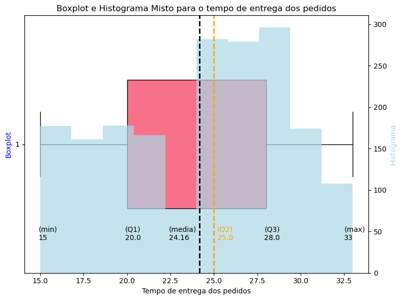

```python
# delivery_time

# Visualização de dados usando gráfico misto de boxplot e histograma para a coluna delivery_time

# Defina a paleta de cores desejada
sns.set_palette("husl")

# Criando a figura e os eixos
fig, ax = plt.subplots(figsize=(8, 6))

# Boxplot
ax.boxplot(df['delivery_time'], vert=False, patch_artist=True, widths=0.50)

# Histograma
hist_axes = ax.twinx()
hist_axes.hist(df['delivery_time'], bins=10, color='lightblue', alpha=0.7)

# Adicionando rótulos e título
ax.set_xlabel('Tempo de entrega dos pedidos')
ax.set_ylabel('Boxplot', color='blue')
hist_axes.set_ylabel('Histograma', color='lightblue')
ax.set_title('Boxplot e Histograma Misto para o tempo de entrega dos pedidos')

#inserindo linhas para Q1, Q3, mediana(Q2) e media
plt.text(x = df['delivery_time'].min()-0.1, y = 50, s = '(min)')
plt.text(x = df['delivery_time'].min()-0.1, y = 40, s = df['delivery_time'].min())
#q1 = df['delivery_time'].quantile(0.25)  # valor Q1
#plt.axvline(x=q1, color='red', linestyle='dashed', linewidth=2, label='Linha Q1')
plt.text(x = df['delivery_time'].quantile(0.25)-0.1, y = 50, s = '(Q1)')
plt.text(x = df['delivery_time'].quantile(0.25)-0.1, y = 40, s = df['delivery_time'].quantile(0.25))
#q3 = df['delivery_time'].quantile(0.75)  # valor Q3
#plt.axvline(x=q3, color='red', linestyle='dashed', linewidth=2, label='Linha Q3')
plt.text(x = df['delivery_time'].quantile(0.75)-0.1, y = 50, s = '(Q3)')
plt.text(x = df['delivery_time'].quantile(0.75)-0.1, y = 40, s = round(df['delivery_time'].quantile(0.75),2))
mediana = df['delivery_time'].median()  # mediana(Q2)
plt.axvline(x=mediana, color='orange', linestyle='dashed', linewidth=2, label='Linha da mediana(Q2)')
plt.text(x = df['delivery_time'].median()+0.2, y = 50, s = '(Q2)',color='orange')
plt.text(x = df['delivery_time'].median()+0.2, y = 40, s = df['delivery_time'].median(),color='orange')
media = df['delivery_time'].mean()  # media
plt.axvline(x=media, color='black', linestyle='dashed', linewidth=2, label='Linha da média')
plt.text(x = df['delivery_time'].mean()-1.75, y = 50, s = '(media)')
plt.text(x = df['delivery_time'].mean()-1.75, y = 40, s = round(df['delivery_time'].mean(),2))
plt.text(x = df['delivery_time'].max()-0.5, y = 50, s = '(max)')
plt.text(x = df['delivery_time'].max()-0.5, y = 40, s = df['delivery_time'].max())

# Ajustando o layout
plt.tight_layout()

# Exibindo o gráfico
plt.show()
```

##### **Pergunta 7**: Quais são os 5 melhores restaurantes em termos de número de pedidos recebidos? [1 ponto]

```python
# Write the code here
df['restaurant_name'].value_counts().sort_values(ascending=False).head()
# Usamos novamente a função value_counts() que conta a quantidade de pedidos agrupando pelo nome de cada restaurante
# Usamos a função head() que traz os cinco primeiros resultados que já estavam ordenados de maior para menor
```

```
restaurant_name
Shake Shack                  219
The Meatball Shop            132
Blue Ribbon Sushi            119
Blue Ribbon Fried Chicken     96
Parm                          68
Name: count, dtype: int64
```

#### Observações:

Os cinco melhores restaurantes em termo de número de pedidos são:

- 1º Shake Shack com 219 pedidos
- 2º The Meatball Shop com 132 pedidos
- 3º Blue Ribbon Sushi com 119 pedidos
- 4º Blue Ribbon Fried Chicken com 96 pedidos
- 5º Parm com 68 pedidos

### **Pergunta 8**: Qual é a culinária mais popular nos finais de semana? [1 ponto]

```python
# Write the code here
print("Resumo de pedidos por dia da semana: coluna",df['day_of_the_week'].value_counts(),"\n")
# Criamos o DataFrame df_fds que extrai somente os registros cujo valor na coluna day_of_the_week é igual a Weekend
# Assim temos um DataFrame com pedidos somente de final de semana
df_fds = df[df['day_of_the_week']=='Weekend']
# Neste novo DataFrame usamos a função value_counts() contando a quantidade de pedidos de final de semana por culinária
# Usamos a função head(1) para extrair a primeira colocada, ou seja, a mais popular
print("Culinária mais popular de final de semana:", df_fds['cuisine_type'].value_counts().head(1).index[0],"com o total de",df_fds['cuisine_type'].value_counts().head(1).values[0],"pedidos.")
```

```
Resumo de pedidos por dia da semana: coluna day_of_the_week
Weekend    1351
Weekday     547
Name: count, dtype: int64

Culinária mais popular de final de semana: American com o total de 415 pedidos.
```

#### Observações:

A culinária mais popular de final de semana é a Americana, com um total de 415 pedidos.

### **Pergunta 9**: Qual a porcentagem dos pedidos que custaram mais de 20 dólares? [2 pontos]

```python
# Write the code here
qtd_acima_20_dolares = np.count_nonzero(df[df['cost_of_the_order']>20]['order_id'])
total_pedidos = df.shape[0]
print("Foram",qtd_acima_20_dolares,"pedidos com custo acima de 20 dólares de um total de",total_pedidos,"pedidos.")
print("Ou seja,",round((qtd_acima_20_dolares/df.shape[0])*100,2),"% dos pedidos custaram mais que 20 dólares.")
```

```
Foram 555 pedidos com custo acima de 20 dólares de um total de 1898 pedidos.
Ou seja, 29.24 % dos pedidos custaram mais que 20 dólares.
```

#### Observações:

**Resposta:** 29,24% dos pedidos custaram mais de 20 dólares

### **Pergunta 10**: Qual é a média de tempo de entrega do pedido? [1 ponto]

```python
# Write the code here
# Usamos a função mean() para calcular a média do tempo de entrega, usando os dados da coluna delivery_time
# Usamos a função round() para arredodar e também informar quantas casas decimais queremos após a vírgula (ponto)
print("A média de tempo de entrega do pedido é",round(df['delivery_time'].mean(),2),"minutos")
```

```
A média de tempo de entrega do pedido é 24.16 minutos
```

#### Observações:

**Resposta:** O tempo médio de entrega de um pedido é de 24,16 minutos

### **Pergunta 11:** A empresa decidiu dar cupons de desconto de 20% aos 3 clientes mais frequentes. Encontre os IDs desses clientes e o número total de pedidos eles fizeram. [1 ponto]

```python
# Write the code here
clientes_mais_frequentes = df['customer_id'].value_counts().sort_values(ascending=False).head(3)
print(clientes_mais_frequentes,"\n")
print("1º cliente id",clientes_mais_frequentes.index[0],"com",clientes_mais_frequentes.values[0],"pedidos")
print("2º cliente id",clientes_mais_frequentes.index[1],"com",clientes_mais_frequentes.values[1],"pedidos")
print("3º cliente id",clientes_mais_frequentes.index[2],"com",clientes_mais_frequentes.values[2],"pedidos")
```

```
customer_id
52832    13
47440    10
83287     9
Name: count, dtype: int64

1º cliente id 52832 com 13 pedidos
2º cliente id 47440 com 10 pedidos
3º cliente id 83287 com 9 pedidos
```

#### Observações:

**Resposta:** Os 3 clientes que ganharam os cupons de desconto de 20% foram:

- 1º Cliente ID 52832 com 13 pedidos
- 2º Cliente ID 47440 com 10 pedidos
- 3º Cliente ID 83287 com 9 pedidos

### **Pergunta 12**: Realize uma análise multivariada para explorar as relações entre as variáveis importantes do conjunto de dados. (É uma boa ideia explorar as relações entre as variáveis numéricas, bem como as relações entre variáveis numéricas e categóricas) [10 pontos]

```python
# Write the code here
# Colunas order_id e customer_id não foram utilizadas na análise multivariada pois contém muitos registros únicos

# Coluna restaurant_name em relação as duas primeiras possibilida melhor distribuição e análise

print("\nDez restaurantes com maior faturamento (em dolares):\n",df.groupby(['restaurant_name'])['cost_of_the_order'].sum().sort_values(ascending = False).head(10))
print("\nDez restaurantes com menor tempo médio de preparação do pedido (em minutos):\n",df.groupby(['restaurant_name'])['food_preparation_time'].mean().sort_values(ascending = True).head(10))
print("\nDez restaurantes com menor tempo médio de entrega do pedido (em minutos):\n",df.groupby(['restaurant_name'])['delivery_time'].mean().sort_values(ascending = True).head(10))

df['Tempo Total'] = df['food_preparation_time']+df['delivery_time']
print("\nDez restaurantes com menor média do tempo total da preparação até a entrega(em minutos):\n",df.groupby(['restaurant_name'])['Tempo Total'].mean().sort_values(ascending = True).head(10))
```

```
Dez restaurantes com maior faturamento (em dolares):
 restaurant_name
Shake Shack                      3579.53
The Meatball Shop                2145.21
Blue Ribbon Sushi                1903.95
Blue Ribbon Fried Chicken        1662.29
Parm                             1112.76
RedFarm Broadway                  965.13
RedFarm Hudson                    921.21
TAO                               834.50
Han Dynasty                       755.29
Blue Ribbon Sushi Bar & Grill     666.62
Name: cost_of_the_order, dtype: float64

Dez restaurantes com menor tempo médio de preparação do pedido (em minutos):
 restaurant_name
Haru Gramercy Park            20.0
67 Burger                     20.0
Frank Restaurant              20.0
DespaÌ±a                      20.5
Sarabeth's West               21.0
Lucky Strike                  21.0
Song Thai Restaurant & Bar    21.0
Hampton Chutney Co.           21.0
Samurai Mama                  21.0
Market Table                  21.0
Name: food_preparation_time, dtype: float64

Dez restaurantes com menor tempo médio de entrega do pedido (em minutos):
 restaurant_name
Gaia Italian Cafe    15.0
Paul & Jimmy's       15.0
The MasalaWala       15.0
Hibino               15.0
Coppola's East       16.0
Galli Restaurant     16.0
Wo Hop Restaurant    16.0
Market Table         17.0
Byblos Restaurant    18.0
Samurai Mama         18.0
Name: delivery_time, dtype: float64

Dez restaurantes com menor média do tempo total da preparação até a entrega(em minutos):
 restaurant_name
Wo Hop Restaurant      38.0
Market Table           38.0
Galli Restaurant       38.0
Samurai Mama           39.0
DespaÌ±a               40.0
Gaia Italian Cafe      40.0
Hampton Chutney Co.    41.0
Lucky Strike           42.0
Lamarca Pasta          42.0
Socarrat Paella Bar    43.0
Name: Tempo Total, dtype: float64
```

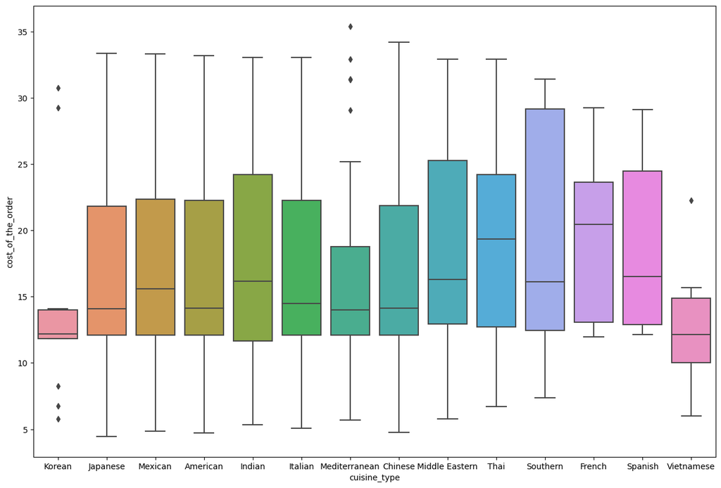

```python
#cuisine_type em relação as demais variáveis (cost_of_the_order,food_preparation_time,delivery_time,rating,day_of_the_week)

#cuisine_type x cost_of_the_order

# Defina a paleta de cores desejada
sns.set_palette("husl")

plt.figure(figsize=(15,10))
sns.boxplot(x=df['cuisine_type'],y=df['cost_of_the_order'],data=df)
plt.show()
```

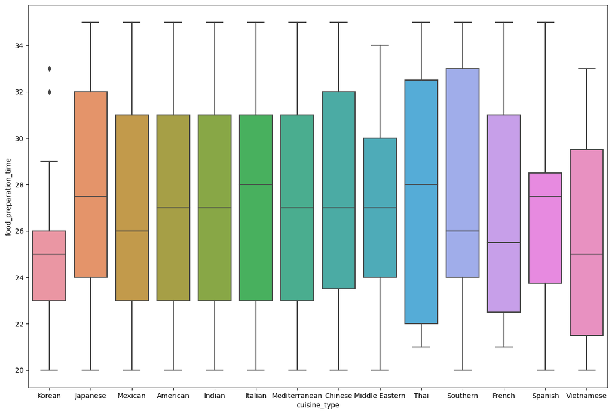

```python
#cuisine_type x food_preparation_time

# Defina a paleta de cores desejada
sns.set_palette("husl")

plt.figure(figsize=(15,10))
sns.boxplot(x=df['cuisine_type'],y=df['food_preparation_time'],data=df)
plt.show()
```

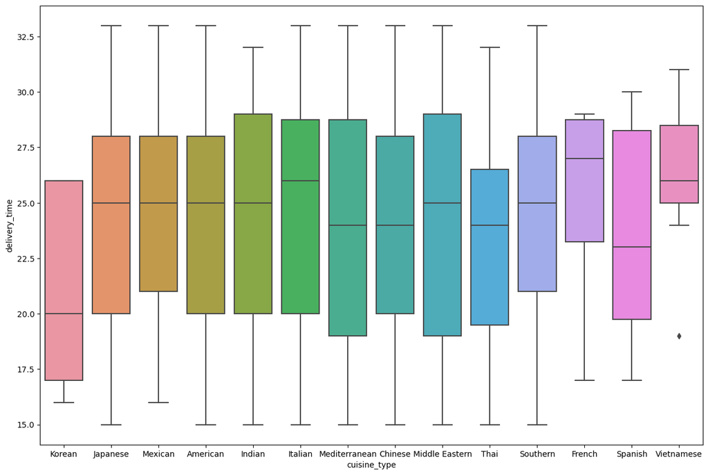

```python
#cuisine_type x delivery_time

# Defina a paleta de cores desejada
sns.set_palette("husl")

plt.figure(figsize=(15,10))
sns.boxplot(x=df['cuisine_type'],y=df['delivery_time'],data=df)
plt.show()
```

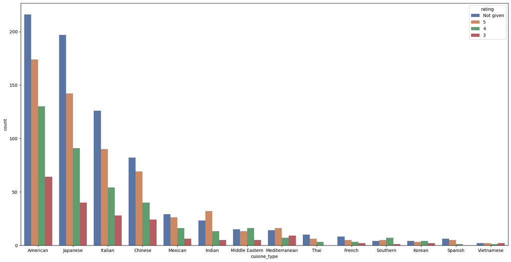

```python
#cuisine_type x rating

# Defina a paleta de cores desejada
sns.set_palette("deep")

plt.figure(figsize=(20,10))
sns.countplot(data=df, x=df['cuisine_type'], order=df['cuisine_type'].value_counts().sort_values(ascending=False).index,hue = df['rating'], hue_order=df['rating'].value_counts().sort_values(ascending=False).index)
plt.show()
```

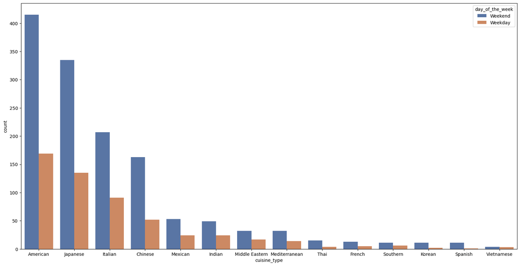

```python
#cuisine_type x day_of_the_week

# Defina a paleta de cores desejada
sns.set_palette("deep")

plt.figure(figsize=(20,10))
sns.countplot(data=df, x=df['cuisine_type'], order=df['cuisine_type'].value_counts().sort_values(ascending=False).index,hue = df['day_of_the_week'])
plt.show()
```

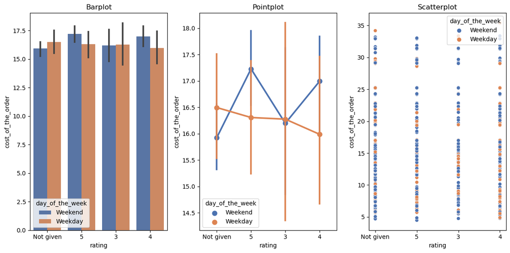

```python
# Rating em relação as outras variáveis (cost_of_the_order,food_preparation_time,delivery_time,day_of_the_week)


# Rating x cost_of_the_order
# Criando subgráficos
fig, axs = plt.subplots(1, 3, figsize=(12, 6))

sns.set_palette("deep")

# Gráfico de barras categóricas (Catplot)
sns.barplot(x='rating', y='cost_of_the_order', hue='day_of_the_week', data=df, ax=axs[0])
axs[0].set_title("Barplot")

# Gráfico de ponto (Pointplot)
sns.pointplot(x='rating', y='cost_of_the_order', hue='day_of_the_week', data=df, ax=axs[1])
axs[1].set_title("Pointplot")

# Gráfico de ponto (Scatterplot)
sns.scatterplot(x='rating', y='cost_of_the_order', hue='day_of_the_week', data=df, ax=axs[2])
axs[2].set_title("Scatterplot")

# Ajustando o layout
plt.tight_layout()

# Exibindo a figura
plt.show()
```

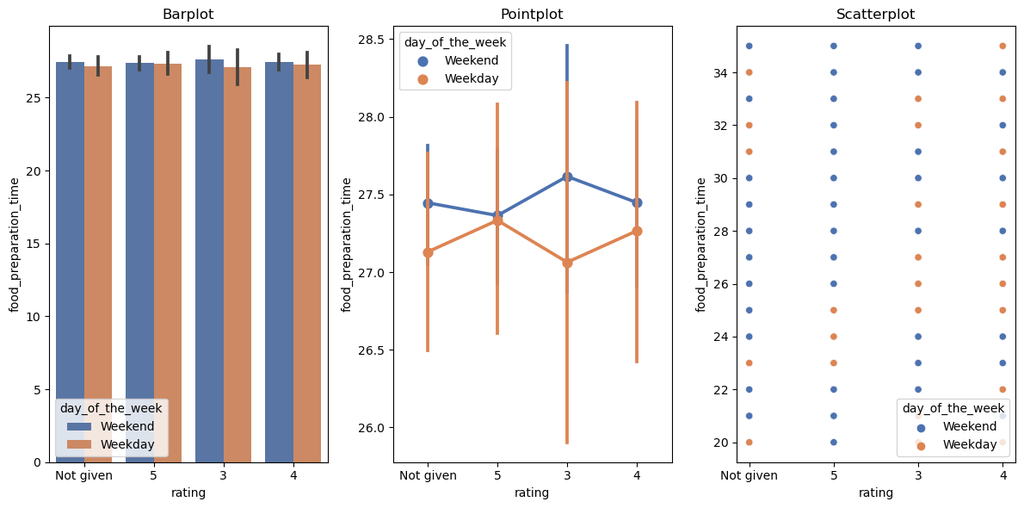

```python
# Rating x food_preparation_time
# Criando subgráficos
fig, axs = plt.subplots(1, 3, figsize=(12, 6))

sns.set_palette("deep")

# Gráfico de barras categóricas (Catplot)
sns.barplot(x='rating', y='food_preparation_time', hue='day_of_the_week', data=df, ax=axs[0])
axs[0].set_title("Barplot")

# Gráfico de ponto (Pointplot)
sns.pointplot(x='rating', y='food_preparation_time', hue='day_of_the_week', data=df, ax=axs[1])
axs[1].set_title("Pointplot")

# Gráfico de ponto (Scatterplot)
sns.scatterplot(x='rating', y='food_preparation_time', hue='day_of_the_week', data=df, ax=axs[2])
axs[2].set_title("Scatterplot")

# Ajustando o layout
plt.tight_layout()

# Exibindo a figura
plt.show()
```

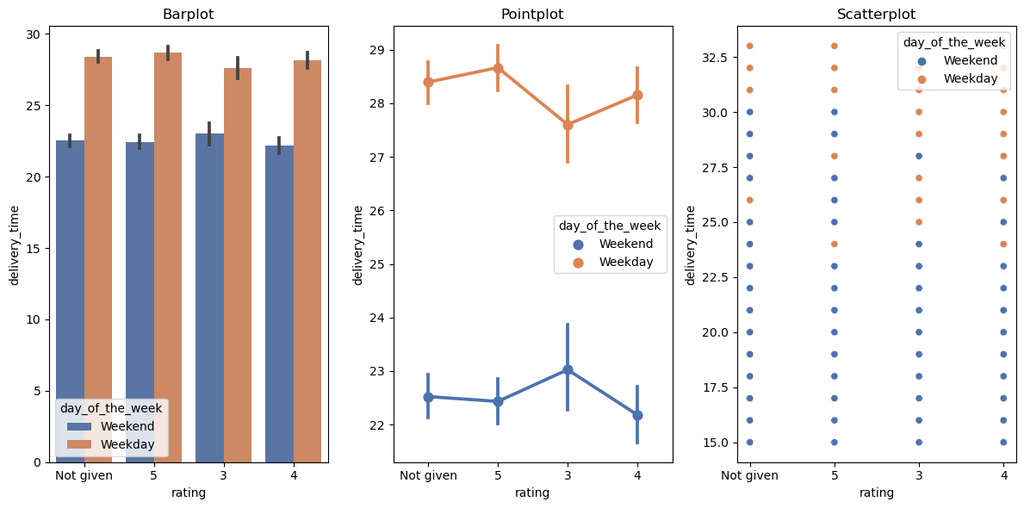

```python
# Rating x delivery_time
# Criando subgráficos
fig, axs = plt.subplots(1, 3, figsize=(12, 6))

sns.set_palette("deep")

# Gráfico de barras categóricas (Catplot)
sns.barplot(x='rating', y='delivery_time', hue='day_of_the_week', data=df, ax=axs[0])
axs[0].set_title("Barplot")

# Gráfico de ponto (Pointplot)
sns.pointplot(x='rating', y='delivery_time', hue='day_of_the_week', data=df, ax=axs[1])
axs[1].set_title("Pointplot")

# Gráfico de ponto (Scatterplot)
sns.scatterplot(x='rating', y='delivery_time', hue='day_of_the_week', data=df, ax=axs[2])
axs[2].set_title("Scatterplot")

# Ajustando o layout
plt.tight_layout()

# Exibindo a figura
plt.show()
```

```
Visualização de Dados usando gráfico Heatmap para as variáveis numéricas:
```

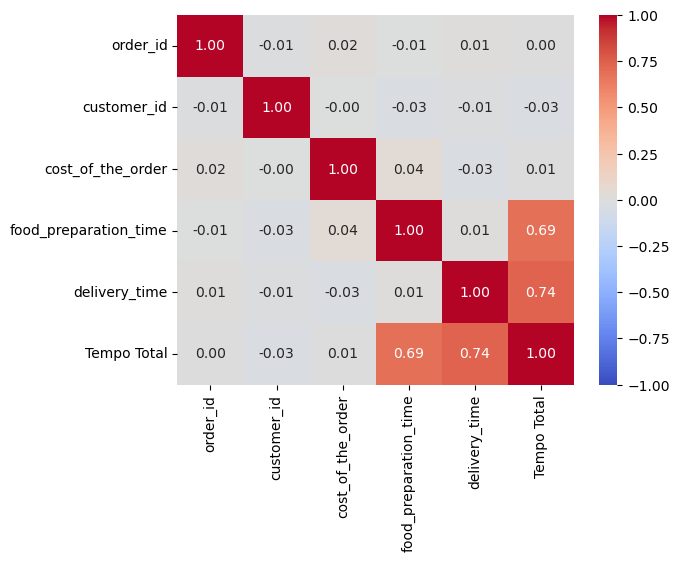

```
Visualização de Dados usando gráfico Heatmap para as variáveis numéricas e categóricas:
```

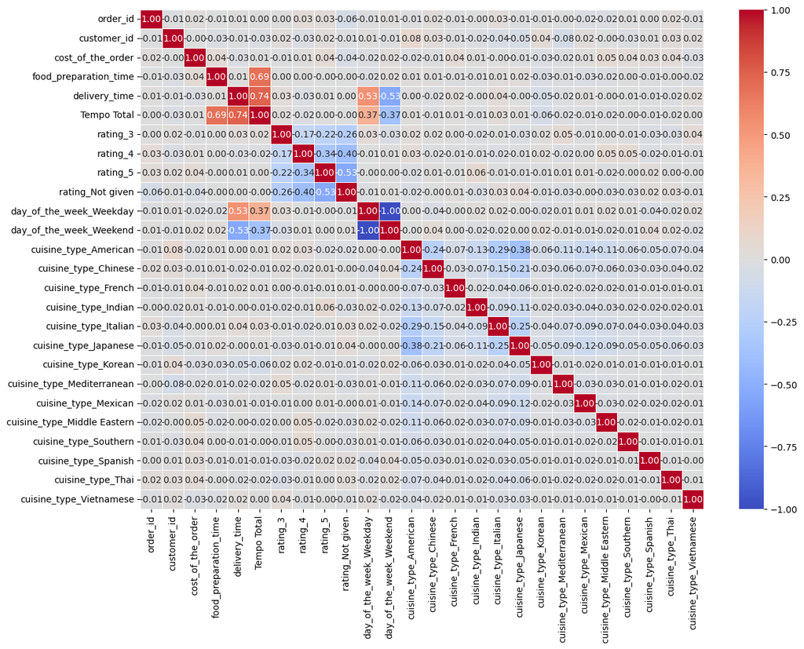

```python
# Relação de todas as variáveis numéricas (int, float)

# Criar DataFrame com apenas as variáveis numéricas
df_somente_numericas = df.select_dtypes(include='number')

# Fazer a correção das variáveis numéricas
df_correlacao_somente_numericas = df_somente_numericas.corr()

# Visualizar a correlação usando o gráfico heatmap
sns.heatmap(df_correlacao_somente_numericas, vmin=-1, vmax=1,annot=True,fmt=".2f",cmap='coolwarm')
print("Visualização de Dados usando gráfico Heatmap para as variáveis numéricas:\n")
plt.show()


# Relação de todas as variáveis numéricas e categóricas

# Criar DataFrame onde para as variáveis categóricas criamos colunas delas com valores booleanos
# O método usado para isto é a função get_dummies do panda
df_transf_categoricas_em_booleanas = pd.get_dummies(df,columns=['rating','day_of_the_week','cuisine_type'])

# Criamos novo DataFrame onde selecionamos apenas o valores numéricos e booleanos, excluindo os valores categóricos
df_exclui_categoricas = df_transf_categoricas_em_booleanas.select_dtypes(include=['number','bool'])

# Fazer a correção de todas estas variáveis
df_correlacao_total = df_exclui_categoricas.corr()

# Ajustando o tamanho da figura
plt.figure(figsize=(14, 10))

# Visualizar a correlação usando o gráfico heatmap
sns.heatmap(df_correlacao_total, vmin=-1, vmax=1,annot=True,fmt=".2f",cmap='coolwarm',linewidths=.5)
print("Visualização de Dados usando gráfico Heatmap para as variáveis numéricas e categóricas:\n")
plt.show()
```

### **Pergunta 13:** A empresa deseja fornecer uma oferta promocional na propaganda dos restaurantes. A condição para obter a oferta é que os restaurantes tenham uma contagem de avaliação superior a 50 e a avalição média deve ser superior a 4. Encontre os restaurantes que atendem aos critérios para obter a oferta promocional. [3 pontos]

```python
# Write the code here
# Montamos o DataFrame df_pedidos_avaliados extraindo somente os pedidos avaliados
df_pedidos_avaliados = df[df['rating']!='Not given'].copy()
# Conversão da coluna rating de object para int
df_pedidos_avaliados['rating']=df_pedidos_avaliados['rating'].astype('int')

# Contagem de pedidos avaliados por restaurante e seleção dos restaurantes com mais de 50 avaliações
df_contagem_restaurantes_pedidos_avaliados = df_pedidos_avaliados.groupby(['restaurant_name'])['rating'].count().sort_values(ascending= False).reset_index()
df_restaurantes_qtd_avaliacao_sup50 = df_contagem_restaurantes_pedidos_avaliados[df_contagem_restaurantes_pedidos_avaliados['rating']>50]
print("Restaurantes com mais de 50 avaliações:\n\n",df_restaurantes_qtd_avaliacao_sup50,"\n\n")

# Cálculo da média dos pedidos avaliados e a seleção dos restaurantes com média de avaliação acima de 4
df_media_restaurantes_pedidos_avaliados = df_pedidos_avaliados.groupby(['restaurant_name'])['rating'].mean().sort_values(ascending= False).reset_index()
df_restaurantes_media_avaliacao_acima4 = df_media_restaurantes_pedidos_avaliados[df_media_restaurantes_pedidos_avaliados['rating']>4]
print("Restaurantes com avaliação média superior a 4:\n\n",df_restaurantes_media_avaliacao_acima4)

# União tipo inner, onde selecionamos os restaurantes que tem mais de 50 avaliações e média de avaliação acima de 4
print("\n\nRestaurantes com mais de 50 avaliações e média de avaliação acima de 4:\n\n")
df_junto = pd.merge(df_restaurantes_qtd_avaliacao_sup50, df_restaurantes_media_avaliacao_acima4, on='restaurant_name', how='inner')
df_junto
```

```
Restaurantes com mais de 50 avaliações:

              restaurant_name  rating
0                Shake Shack     133
1          The Meatball Shop      84
2          Blue Ribbon Sushi      73
3  Blue Ribbon Fried Chicken      64


Restaurantes com avaliação média superior a 4:

                    restaurant_name    rating
0                       'wichcraft  5.000000
1             Ravagh Persian Grill  5.000000
2    Chola Eclectic Indian Cuisine  5.000000
3                      Chote Nawab  5.000000
4                           Junoon  5.000000
..                             ...       ...
105                   Cafe Mogador  4.153846
106               ilili Restaurant  4.153846
107                           Parm  4.128205
108                       Rubirosa  4.125000
109                     Bareburger  4.058824

[110 rows x 2 columns]


Restaurantes com mais de 50 avaliações e média de avaliação acima de 4:
```

|  | restaurant_name | rating_x | rating_y |
| --- | --- | --- | --- |
| 0 | Shake Shack | 133 | 4.278195 |
| 1 | The Meatball Shop | 84 | 4.511905 |
| 2 | Blue Ribbon Sushi | 73 | 4.219178 |
| 3 | Blue Ribbon Fried Chicken | 64 | 4.328125 |

#### Observações:

### **Pergunta 14:** A empresa cobra dos restaurantes 25% nos pedidos de valor superior a 20 dólares e 15% nos pedidos de valor superior a 5 dólares. Encontre a receita líquida gerada pela empresa em todos os pedidos. [3 pontos]

```python
# Write the code here
# Declaração de variaveis que serão usadas
qtd_pedidos_acima_20_dolares = 0
receita_pedidos_acima_20_dolares = 0
qtd_pedidos_acima_5_ate_20_dolares = 0
receita_pedidos_acima_5_ate_20_dolares = 0
qtd_pedidos_sem_receita = 0

# Loop que levanta todos os valores da coluna cost_of_order e calcula quantidades e receitas geradas
for i in df['cost_of_the_order'].values:
    if i > 20 :
        qtd_pedidos_acima_20_dolares += 1
        receita_pedidos_acima_20_dolares = receita_pedidos_acima_20_dolares + (i*0.25)
    elif i>5:
        qtd_pedidos_acima_5_ate_20_dolares += 1
        receita_pedidos_acima_5_ate_20_dolares = receita_pedidos_acima_5_ate_20_dolares + (i*0.15)
    else:
        qtd_pedidos_sem_receita+=1

# Novas variaveis que armazenam a quantidade total de pedidos com receita e a receita líquida total
qtd_total_pedidos_com_receita = qtd_pedidos_acima_20_dolares + qtd_pedidos_acima_5_ate_20_dolares
receita_total = receita_pedidos_acima_20_dolares + receita_pedidos_acima_5_ate_20_dolares

print("Quantidade de pedidos acima de 20 dólares:",qtd_pedidos_acima_20_dolares)
print("Receita dos pedidos acima de 20 dólares: $",round(receita_pedidos_acima_20_dolares,2),"\n\n")

print("Quantidade de pedidos acima de 5 dólares até 20 dólares:",qtd_pedidos_acima_5_ate_20_dolares)
print("Receita dos pedidos acima de 5 dólares até 20 dólares: $",round(receita_pedidos_acima_5_ate_20_dolares,2),"\n\n")

print("Quantidade de pedidos sem receita:",qtd_pedidos_sem_receita)
print("Quantidade de pedidos com receita:",qtd_total_pedidos_com_receita)
print("Receita líquida total gerada: $",round(receita_total,2))
```

```
Quantidade de pedidos acima de 20 dólares: 555
Receita dos pedidos acima de 20 dólares: $ 3688.73


Quantidade de pedidos acima de 5 dólares até 20 dólares: 1334
Receita dos pedidos acima de 5 dólares até 20 dólares: $ 2477.58


Quantidade de pedidos sem receita: 9
Quantidade de pedidos com receita: 1889
Receita líquida total gerada: $ 6166.3
```

#### Observações:

### **Pergunta 15:** A empresa deseja analisar o tempo total necessário para a entrega do pedido. Qual a porcentagem de pedidos que levam mais de 60 minutos para serem entregues a partir do momento em que ele é feito? (A comida deve ser preparada e depois entregue.) [2 pontos]

```
Quantidade de pedidos acima de 60 minutos: 200
Quantidade total de pedidos 1898
Percentual de pedidos acima de 60 minutos: 10.54 %
```

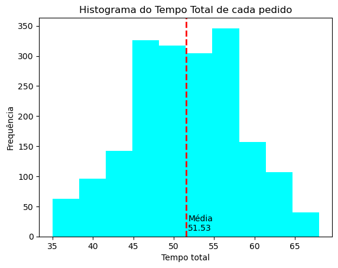

```python
# Write the code here
# Criar uma coluna que faça o calculo total de tempo por pedido (soma das colunas food_preparatin_time e delivery_time)
df['Tempo Total']= df['food_preparation_time']+df['delivery_time']
pedidos_acima_60_minutos = df[df['Tempo Total']>60]
print("Quantidade de pedidos acima de 60 minutos:", pedidos_acima_60_minutos.shape[0])
print("Quantidade total de pedidos", df.shape[0])
print("Percentual de pedidos acima de 60 minutos:", round((pedidos_acima_60_minutos.shape[0]/df.shape[0])*100,2),"%")

plt.hist(df['Tempo Total'],color='cyan', bins=10)
plt.title('Histograma do Tempo Total de cada pedido')
plt.xlabel("Tempo total")
plt.ylabel("Frequência")
plt.axvline(x=df['Tempo Total'].mean(), color='red', linestyle='dashed', linewidth=2, label='média do tempo total')
plt.text(x = df['Tempo Total'].mean()+0.25, y = 25, s = 'Média')
plt.text(x = df['Tempo Total'].mean()+0.25, y = 10, s = round(df['Tempo Total'].mean(),2))

plt.show()
```

#### Observações:

### **Pergunta 16:** A empresa deseja analisar o prazo de entrega dos pedidos no meio da semana e aos finais de semana. Como o tempo médio de entrega varia durante a semana e em fins de semana? [2 pontos]

```
A média do prazo de entrega (em minutos) para pedidos em finais de semana é: 22.47
A média do prazo de entrega (em minutos) para pedidos em dias da semana é: 28.34
```

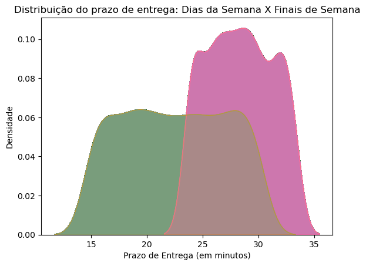

```python
# Write the code here# Defina a paleta de cores desejada
sns.set_palette("husl")
import warnings
warnings.filterwarnings('ignore')

# Criamos o DataFrame df_fds que extrai somente os registros cujo valor na coluna day_of_the_week é igual a Weekend
# Assim temos um DataFrame com pedidos somente de final de semana
df_fds = df[df['day_of_the_week']=='Weekend']
# Criamos o DataFrame df_dias_semana que extrai somente os registros cujo valor na coluna day_of_the_week é igual a Weekday
# Assim temos um DataFrame com pedidos somente de dias da semana
df_dias_semana = df[df['day_of_the_week']=='Weekday']

print("A média do prazo de entrega (em minutos) para pedidos em finais de semana é:",round(df_fds['delivery_time'].mean(),2))
print("A média do prazo de entrega (em minutos) para pedidos em dias da semana é:",round(df_dias_semana['delivery_time'].mean(),2))



# Loop sobre os dias da semana
for i in df['day_of_the_week'].values:
    subset = df[df['day_of_the_week']==i]
    sns.distplot(subset['delivery_time'], hist=False, kde = True, kde_kws={'fill':True}, label=i)

# Adicione rótulos e título
plt.xlabel('Prazo de Entrega (em minutos)')
plt.ylabel('Densidade')
plt.title('Distribuição do prazo de entrega: Dias da Semana X Finais de Semana')


# Exiba o gráfico
plt.show()
```

#### Observações:

Em analise aos dados e a visualização deles no distplot, percebemos que a média do prazo de entrega para os pedidos feitos durante a semana (28,34 minutos) é superior a média do prazo de entrega dos pedidos feitos durante o final de semana (22,47 minutos).

### Conclusão e recomendações

### **Pergunta 17:** Quais são suas conclusões da análise? Quais recomendações você gostaria de compartilhar para ajudar a melhorar o negócio? (Você pode usar o tipo de culinária e os feedbacks de avaliação para orientar suas recomendações de negócios.) [6 pontos]

### Conclusões:

- 82,5% dos pedidos em 4 tipos de culinária:
  - Americana - 584 pedidos
  - Japonesa - 470 pedidos
  - Italiana - 298 pedidos
  - Chinesa - 215 pedidos
- 38,7% dos pedidos não são avaliados (736 dos pedidos com valor 'Not given')
- 71,2% dos pedidos são feitos nos finais de semana (1351 dos pedidos com valor 'Weekend')
- Na resposta da Pergunta 16, vemos que o tempo de entrega (delivery_time) para os pedidos feitos durante a semana (day_of_the_week com valor Weekday) é 26% superior em relação ao tempo de entrega dos pedidos feitos nos finais de semana:
  - A média do prazo de entrega (em minutos) para pedidos em finais de semana é: 22.47
  - A média do prazo de entrega (em minutos) para pedidos em dias da semana é: 28.34

### Recomendações:

- Estimular a avaliação dos pedidos, pois mais de um terço deles não foram avaliados.
- Verificar o motivo que leva o prazo de entrega nos pedidos feitos durante semana ser 26% superior em relação aos pedidos feitos nos finais de semana.
  - Será este um motivo que leva ao menor número de pedidos durante semana? Afinal, a disponibilidade de tempo é importante para os cliente que estão nas suas rotinas de trabalho e estudo?
  - Existe pouca disponibilidade de entregadores para fazer a entrega durante a semana, o que poderia justificar este tempo elevado?
  - O que ocorreria com a melhoria deste indicador?